# Bellabeat Case Analysis

2023-09-08

Eltayeb Yousif

- About Bella beat
- Objective
- Task
- Loading Packages
- Importing data
- Uploading Datasets
- Renaming Datasets
- Fixing the Datasets
  - Looking for duplicates
  - Fixing duplicates
  - Cleaning the datasets
- Analyzing the data
- Summary and Reccomendations to the company
  - Target market
  - what they need to do to improve

## About Bella beat

Bellabeat, a high-tech company that manufactures health-focused smart products for women. The founder Urška Sršen and Sando Mur,developed beautifully designed technology that informs and inspires women around the world. Collecting data on activity, sleep, stress, and reproductive health has allowed Bellabeat to empower women with knowledge about their own health and habits

## Objective

1. What are some trends in smart device usage?
2. How could these trends apply to Bellabeat customers?
3. How could these trends help influence Bellabeat marketing strategy?

## Task

Analyze smart device usage data in order to gain insight into how consumers use non-Bellabeat smart devices

## Loading Packages

```r
library("tidyr")
library("janitor")
library("here")
library("skimr")
library("lubridate")
```

```r
library("ggplot2")
library("tidyverse")
```

## Importing data

For this case study I will use the provided Fitbit Tracker [data](https://www.kaggle.com/datasets/arashnic/fitbit) Reading the excel files prior to the analysis, there has been some file merging in the Daily Activity excel file. This will make the process easier. The files that I will be using are the following:

- Daily Activity
- Calories Daily
- Intensities Daily
- Sleep Daily

## Uploading Datasets

```r
dailyActivity_merged <- read_csv("Fitbit_tracker_data/Fitabase Data 4.12.16-5.12.16/dailyActivity_merged.csv")
dailyCalories_merged <- read_csv("Fitbit_tracker_data/Fitabase Data 4.12.16-5.12.16/dailyCalories_merged.csv")
dailyIntensities_merged <- read_csv("Fitbit_tracker_data/Fitabase Data 4.12.16-5.12.16/dailyIntensities_merged.csv")
sleepDay_merged <- read_csv("Fitbit_tracker_data/Fitabase Data 4.12.16-5.12.16/sleepDay_merged.csv")
Activity_daily <- dailyActivity_merged
Calories_daily <- dailyCalories_merged
intenseties_daily <- dailyIntensities_merged
sleep_daily <- sleepDay_merged
```

## Renaming Datasets

```r
activity_daily <- dailyActivity_merged
calories_daily <- dailyCalories_merged
intenseties_daily <- dailyIntensities_merged
sleep_daily <- sleepDay_merged
```

Now to check the new data sets uploaded and make sure everything was uploaded correctly

```r
head(activity_daily)
```

```
## # A tibble: 6 × 15
##           Id ActivityDate TotalSteps TotalDistance TrackerDistance
##        <dbl> <chr>             <dbl>         <dbl>           <dbl>
## 1 1503960366 4/12/2016         13162          8.5             8.5
## 2 1503960366 4/13/2016         10735          6.97            6.97
## 3 1503960366 4/14/2016         10460          6.74            6.74
## 4 1503960366 4/15/2016          9762          6.28            6.28
## 5 1503960366 4/16/2016         12669          8.16            8.16
## 6 1503960366 4/17/2016          9705          6.48            6.48
## # ℹ 10 more variables: LoggedActivitiesDistance <dbl>,
## #   VeryActiveDistance <dbl>, ModeratelyActiveDistance <dbl>,
## #   LightActiveDistance <dbl>, SedentaryActiveDistance <dbl>,
## #   VeryActiveMinutes <dbl>, FairlyActiveMinutes <dbl>,
## #   LightlyActiveMinutes <dbl>, SedentaryMinutes <dbl>, Calories <dbl>
```

```r
head(calories_daily)
```

```
## # A tibble: 6 × 3
##           Id ActivityDay Calories
##        <dbl> <chr>          <dbl>
## 1 1503960366 4/12/2016       1985
## 2 1503960366 4/13/2016       1797
## 3 1503960366 4/14/2016       1776
## 4 1503960366 4/15/2016       1745
## 5 1503960366 4/16/2016       1863
## 6 1503960366 4/17/2016       1728
```

```r
head(intenseties_daily)
```

```
## # A tibble: 6 × 10
##         Id ActivityDay SedentaryMinutes LightlyActiveMinutes FairlyActiveMinutes
##      <dbl> <chr>                  <dbl>                <dbl>               <dbl>
## 1   1.50e9 4/12/2016                728                  328                  13
## 2   1.50e9 4/13/2016                776                  217                  19
## 3   1.50e9 4/14/2016               1218                  181                  11
## 4   1.50e9 4/15/2016                726                  209                  34
## 5   1.50e9 4/16/2016                773                  221                  10
## 6   1.50e9 4/17/2016                539                  164                  20
## # ℹ 5 more variables: VeryActiveMinutes <dbl>, SedentaryActiveDistance <dbl>,
## #   LightActiveDistance <dbl>, ModeratelyActiveDistance <dbl>,
## #   VeryActiveDistance <dbl>
```

```r
head(sleep_daily)
```

```
## # A tibble: 6 × 5
##           Id SleepDay        TotalSleepRecords TotalMinutesAsleep TotalTimeInBed
##        <dbl> <chr>                       <dbl>              <dbl>          <dbl>
## 1 1503960366 4/12/2016 12:0…                 1                327            346
## 2 1503960366 4/13/2016 12:0…                 2                384            407
## 3 1503960366 4/15/2016 12:0…                 1                412            442
## 4 1503960366 4/16/2016 12:0…                 2                340            367
## 5 1503960366 4/17/2016 12:0…                 1                700            712
## 6 1503960366 4/19/2016 12:0…                 1                304            320
```

## Fixing the Datasets

First we will check for any duplicates

```r
unique(activity_daily$Id)
```

```
##  [1] 1503960366 1624580081 1644430081 1844505072 1927972279 2022484408
##  [7] 2026352035 2320127002 2347167796 2873212765 3372868164 3977333714
## [13] 4020332650 4057192912 4319703577 4388161847 4445114986 4558609924
## [19] 4702921684 5553957443 5577150313 6117666160 6290855005 6775888955
## [25] 6962181067 7007744171 7086361926 8053475328 8253242879 8378563200
## [31] 8583815059 8792009665 8877689391
```

```r
unique(sleep_daily$Id)
```

```
##  [1] 1503960366 1644430081 1844505072 1927972279 2026352035 2320127002
##  [7] 2347167796 3977333714 4020332650 4319703577 4388161847 4445114986
## [13] 4558609924 4702921684 5553957443 5577150313 6117666160 6775888955
## [19] 6962181067 7007744171 7086361926 8053475328 8378563200 8792009665
```

```r
unique(intenseties_daily)
```

```
## # A tibble: 940 × 10
##         Id ActivityDay SedentaryMinutes LightlyActiveMinutes FairlyActiveMinutes
##      <dbl> <chr>                  <dbl>                <dbl>               <dbl>
##  1  1.50e9 4/12/2016                728                  328                  13
##  2  1.50e9 4/13/2016                776                  217                  19
##  3  1.50e9 4/14/2016               1218                  181                  11
##  4  1.50e9 4/15/2016                726                  209                  34
##  5  1.50e9 4/16/2016                773                  221                  10
##  6  1.50e9 4/17/2016                539                  164                  20
##  7  1.50e9 4/18/2016               1149                  233                  16
##  8  1.50e9 4/19/2016                775                  264                  31
##  9  1.50e9 4/20/2016                818                  205                  12
## 10  1.50e9 4/21/2016                838                  211                   8
## # ℹ 930 more rows
## # ℹ 5 more variables: VeryActiveMinutes <dbl>, SedentaryActiveDistance <dbl>,
## #   LightActiveDistance <dbl>, ModeratelyActiveDistance <dbl>,
## #   VeryActiveDistance <dbl>
```

### Looking for duplicates

```r
sum(duplicated(activity_daily))
```

```
## [1] 0
```

```r
sum(duplicated(sleep_daily))
```

```
## [1] 3
```

```r
sum(duplicated(intenseties_daily))
```

```
## [1] 0
```

As stated the following data sets have duplicates :

- activity_daily = 0
- sleep_daily = 3
- intenseties_daily= 0

### Fixing duplicates

```r
sleep_daily <- unique(sleep_daily)
```

Now we can check if there are still duplicates in the dataset.

```r
sum(duplicated(sleep_daily))
```

```
## [1] 0
```

As stated in the code we now have no duplicates in our sleep_daily data set.

### Cleaning the datasets

We will now clean all data sets and make sure the names are in proper name format across all the tables and easy to read.

```r
clean_names(activity_daily)
```

```
## # A tibble: 940 × 15
##            id activity_date total_steps total_distance tracker_distance
##         <dbl> <chr>               <dbl>          <dbl>            <dbl>
##  1 1503960366 4/12/2016           13162           8.5              8.5
##  2 1503960366 4/13/2016           10735           6.97             6.97
##  3 1503960366 4/14/2016           10460           6.74             6.74
##  4 1503960366 4/15/2016            9762           6.28             6.28
##  5 1503960366 4/16/2016           12669           8.16             8.16
##  6 1503960366 4/17/2016            9705           6.48             6.48
##  7 1503960366 4/18/2016           13019           8.59             8.59
##  8 1503960366 4/19/2016           15506           9.88             9.88
##  9 1503960366 4/20/2016           10544           6.68             6.68
## 10 1503960366 4/21/2016            9819           6.34             6.34
## # ℹ 930 more rows
## # ℹ 10 more variables: logged_activities_distance <dbl>,
## #   very_active_distance <dbl>, moderately_active_distance <dbl>,
## #   light_active_distance <dbl>, sedentary_active_distance <dbl>,
## #   very_active_minutes <dbl>, fairly_active_minutes <dbl>,
## #   lightly_active_minutes <dbl>, sedentary_minutes <dbl>, calories <dbl>
```

```r
activity_daily <- rename_with(activity_daily,tolower)

clean_names(sleep_daily)
```

```
## # A tibble: 410 × 5
##          id sleep_day total_sleep_records total_minutes_asleep total_time_in_bed
##       <dbl> <chr>                   <dbl>                <dbl>             <dbl>
##  1   1.50e9 4/12/201…                   1                  327               346
##  2   1.50e9 4/13/201…                   2                  384               407
##  3   1.50e9 4/15/201…                   1                  412               442
##  4   1.50e9 4/16/201…                   2                  340               367
##  5   1.50e9 4/17/201…                   1                  700               712
##  6   1.50e9 4/19/201…                   1                  304               320
##  7   1.50e9 4/20/201…                   1                  360               377
##  8   1.50e9 4/21/201…                   1                  325               364
##  9   1.50e9 4/23/201…                   1                  361               384
## 10   1.50e9 4/24/201…                   1                  430               449
## # ℹ 400 more rows
```

```r
sleep_daily <- rename_with(sleep_daily,tolower)

clean_names(intenseties_daily)
```

```
## # A tibble: 940 × 10
##            id activity_day sedentary_minutes lightly_active_minutes
##         <dbl> <chr>                    <dbl>                  <dbl>
##  1 1503960366 4/12/2016                  728                    328
##  2 1503960366 4/13/2016                  776                    217
##  3 1503960366 4/14/2016                 1218                    181
##  4 1503960366 4/15/2016                  726                    209
##  5 1503960366 4/16/2016                  773                    221
##  6 1503960366 4/17/2016                  539                    164
##  7 1503960366 4/18/2016                 1149                    233
##  8 1503960366 4/19/2016                  775                    264
##  9 1503960366 4/20/2016                  818                    205
## 10 1503960366 4/21/2016                  838                    211
## # ℹ 930 more rows
## # ℹ 6 more variables: fairly_active_minutes <dbl>, very_active_minutes <dbl>,
## #   sedentary_active_distance <dbl>, light_active_distance <dbl>,
## #   moderately_active_distance <dbl>, very_active_distance <dbl>
```

```r
intenseties_daily <- rename_with(intenseties_daily,tolower)
```

Now that all of the table names are under the same format, we will focus on cleaning the date-time format. For sleep_daily the date and time format in the daily_sleep column is in a different format from the rest of the other datasets.The time always equals 12:00:00 AM therefore we will be dropping the unnecessary time. Ensuring a consistent set date-time format throughout the datasets will make merging easier.

```r
activity_daily <- activity_daily %>%
  rename(date = activitydate) %>%
  mutate(date = as_date(date, format = "%m/%d/%Y"))

sleep_daily <- sleep_daily %>%
  rename(date = sleepday) %>%
  mutate(date = as_date(date,format ="%m/%d/%Y %I:%M:%S %p" , tz=Sys.timezone()))
```

Now we can check to see if our code worked.

```r
head(sleep_daily)
```

```
## # A tibble: 6 × 5
##           id date       totalsleeprecords totalminutesasleep totaltimeinbed
##        <dbl> <date>                 <dbl>              <dbl>          <dbl>
## 1 1503960366 2016-04-12                 1                327            346
## 2 1503960366 2016-04-13                 2                384            407
## 3 1503960366 2016-04-15                 1                412            442
## 4 1503960366 2016-04-16                 2                340            367
## 5 1503960366 2016-04-17                 1                700            712
## 6 1503960366 2016-04-19                 1                304            320
```

```r
head(activity_daily)
```

```
## # A tibble: 6 × 15
##           id date       totalsteps totaldistance trackerdistance
##        <dbl> <date>          <dbl>         <dbl>           <dbl>
## 1 1503960366 2016-04-12      13162          8.5             8.5
## 2 1503960366 2016-04-13      10735          6.97            6.97
## 3 1503960366 2016-04-14      10460          6.74            6.74
## 4 1503960366 2016-04-15       9762          6.28            6.28
## 5 1503960366 2016-04-16      12669          8.16            8.16
## 6 1503960366 2016-04-17       9705          6.48            6.48
## # ℹ 10 more variables: loggedactivitiesdistance <dbl>,
## #   veryactivedistance <dbl>, moderatelyactivedistance <dbl>,
## #   lightactivedistance <dbl>, sedentaryactivedistance <dbl>,
## #   veryactiveminutes <dbl>, fairlyactiveminutes <dbl>,
## #   lightlyactiveminutes <dbl>, sedentaryminutes <dbl>, calories <dbl>
```

We are now going to merge both datasets together to create daily_merged

```r
daily_merged <- merge(activity_daily, sleep_daily,by=c ("id", "date"))
glimpse(daily_merged)
```

```
## Rows: 410
## Columns: 18
## $ id                       <dbl> 1503960366, 1503960366, 1503960366, 150396036…
## $ date                     <date> 2016-04-12, 2016-04-13, 2016-04-15, 2016-04-…
## $ totalsteps               <dbl> 13162, 10735, 9762, 12669, 9705, 15506, 10544…
## $ totaldistance            <dbl> 8.50, 6.97, 6.28, 8.16, 6.48, 9.88, 6.68, 6.3…
## $ trackerdistance          <dbl> 8.50, 6.97, 6.28, 8.16, 6.48, 9.88, 6.68, 6.3…
## $ loggedactivitiesdistance <dbl> 0, 0, 0, 0, 0, 0, 0, 0, 0, 0, 0, 0, 0, 0, 0, …
## $ veryactivedistance       <dbl> 1.88, 1.57, 2.14, 2.71, 3.19, 3.53, 1.96, 1.3…
## $ moderatelyactivedistance <dbl> 0.55, 0.69, 1.26, 0.41, 0.78, 1.32, 0.48, 0.3…
## $ lightactivedistance      <dbl> 6.06, 4.71, 2.83, 5.04, 2.51, 5.03, 4.24, 4.6…
## $ sedentaryactivedistance  <dbl> 0, 0, 0, 0, 0, 0, 0, 0, 0, 0, 0, 0, 0, 0, 0, …
## $ veryactiveminutes        <dbl> 25, 21, 29, 36, 38, 50, 28, 19, 41, 39, 73, 3…
## $ fairlyactiveminutes      <dbl> 13, 19, 34, 10, 20, 31, 12, 8, 21, 5, 14, 23,…
## $ lightlyactiveminutes     <dbl> 328, 217, 209, 221, 164, 264, 205, 211, 262, …
## $ sedentaryminutes         <dbl> 728, 776, 726, 773, 539, 775, 818, 838, 732, …
## $ calories                 <dbl> 1985, 1797, 1745, 1863, 1728, 2035, 1786, 177…
## $ totalsleeprecords        <dbl> 1, 2, 1, 2, 1, 1, 1, 1, 1, 1, 1, 1, 1, 1, 1, …
## $ totalminutesasleep       <dbl> 327, 384, 412, 340, 700, 304, 360, 325, 361, …
## $ totaltimeinbed           <dbl> 346, 407, 442, 367, 712, 320, 377, 364, 384, …
```

```r
head(daily_merged)
```

```
##           id       date totalsteps totaldistance trackerdistance
## 1 1503960366 2016-04-12      13162          8.50            8.50
## 2 1503960366 2016-04-13      10735          6.97            6.97
## 3 1503960366 2016-04-15       9762          6.28            6.28
## 4 1503960366 2016-04-16      12669          8.16            8.16
## 5 1503960366 2016-04-17       9705          6.48            6.48
## 6 1503960366 2016-04-19      15506          9.88            9.88
##   loggedactivitiesdistance veryactivedistance moderatelyactivedistance
## 1                        0               1.88                     0.55
## 2                        0               1.57                     0.69
## 3                        0               2.14                     1.26
## 4                        0               2.71                     0.41
## 5                        0               3.19                     0.78
## 6                        0               3.53                     1.32
##   lightactivedistance sedentaryactivedistance veryactiveminutes
```

[output cut: 20 more lines]

We are now done cleaning and formatting the data. We are ready to analyze our dataset.

## Analyzing the data

We want to start by graphing different variables and checking for a correlation or causation.

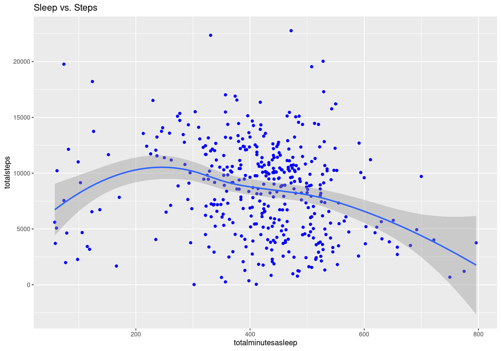

```r
ggplot(data=daily_merged, aes(x=totalminutesasleep, y=totalsteps)) +
    geom_point(color= "blue") + geom_smooth() + labs(title="Sleep vs. Steps")
```

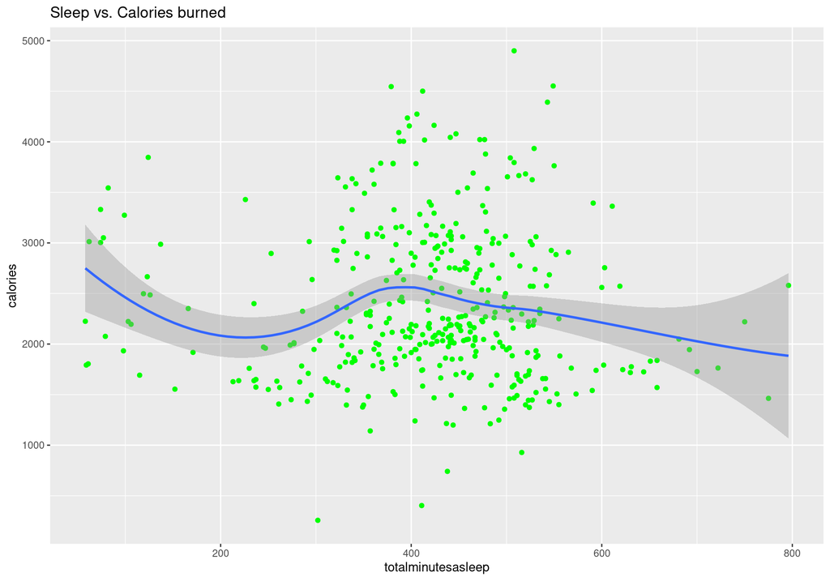

```r
ggplot(data=daily_merged, aes(x=totalminutesasleep, y=calories)) +
  geom_point(color= "green") + geom_smooth() + labs(title="Sleep vs. Calories burned")
```

Just as the previous plot displayed, there is no correlation between sleep and calories burned for the day. Next we will check the relationship between sleep and the time spent in bed.

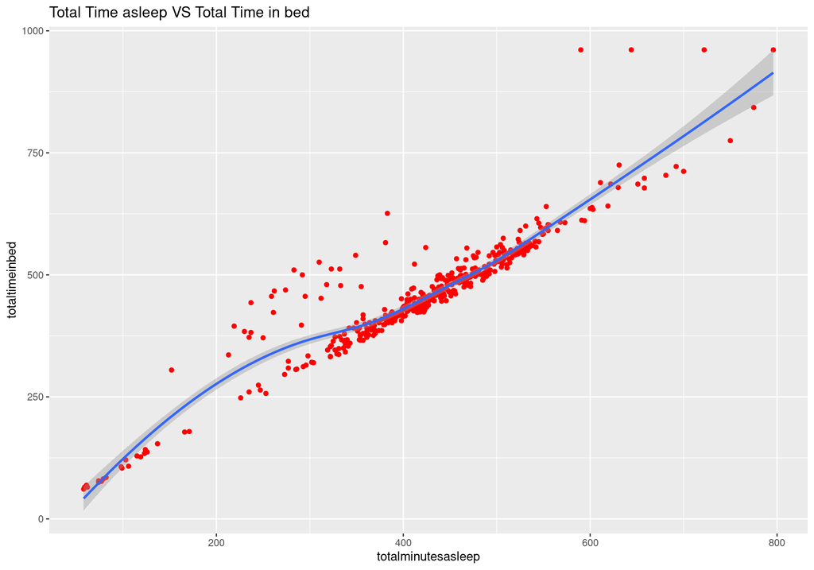

```r
ggplot(data=daily_merged,aes(x=totalminutesasleep,y=totaltimeinbed))+
  geom_point(color="red") + geom_smooth() + labs(title = "Total Time asleep VS Total Time in bed")
```

As shown in the graph the relationship between the time spent in bed and time asleep is linear. This is not surprising as most users get around 400-600 minutes of sleep per day (6.67-10 hours). Next we will check the relationship between total time asleep and sedentary minutes.

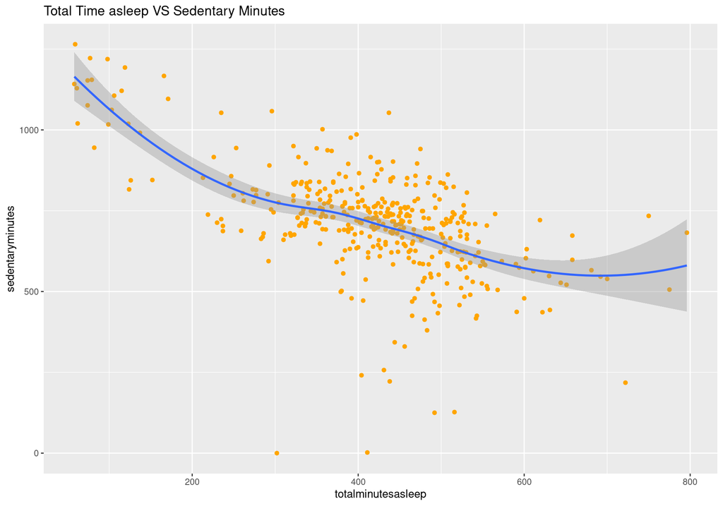

```r
ggplot(data=daily_merged,aes(x=totalminutesasleep,y=sedentaryminutes))+
  geom_point(color="orange") + geom_smooth() + labs(title = "Total Time asleep VS Sedentary Minutes")
```

As shown in the graph there is a negative relationship between the total time asleep and sedentary minutes. Meaning the more time spent sedentary, can effect your total time asleep. Based off this data we can tell the marketing company to tell the customers to spend more active minutes rather than being sedentary. Next we will check the relationship between being lightly active and the total amount of sleep.

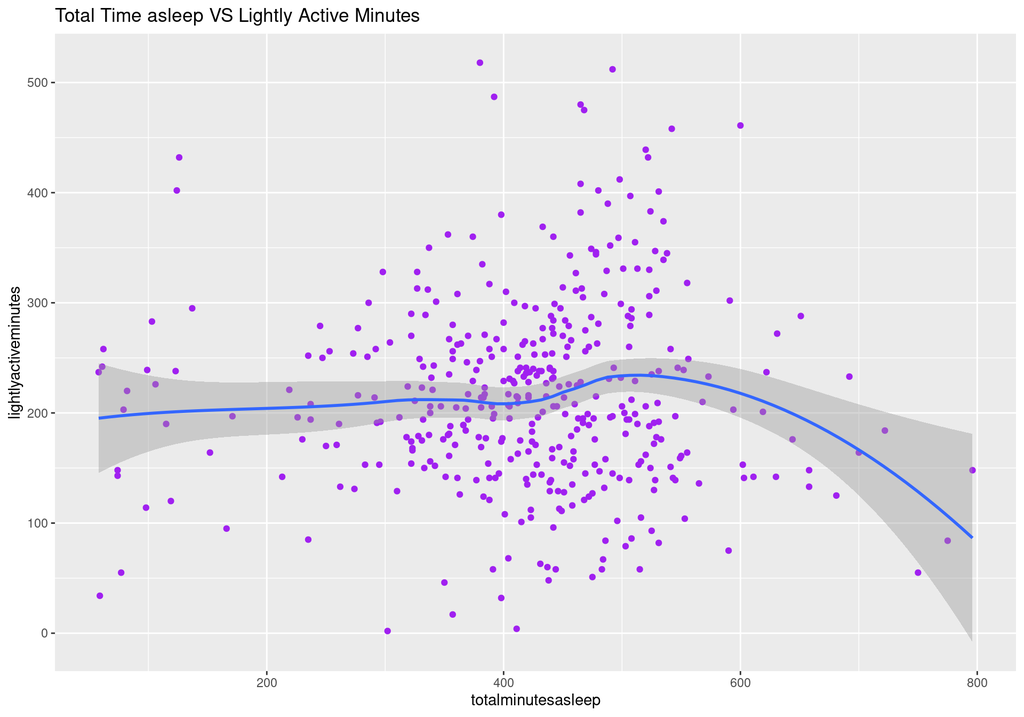

```r
ggplot(data=daily_merged,aes(x=totalminutesasleep,y=lightlyactiveminutes))+
  geom_point(color="purple") + geom_smooth() + labs(title = "Total Time asleep VS Lightly Active Minutes")
```

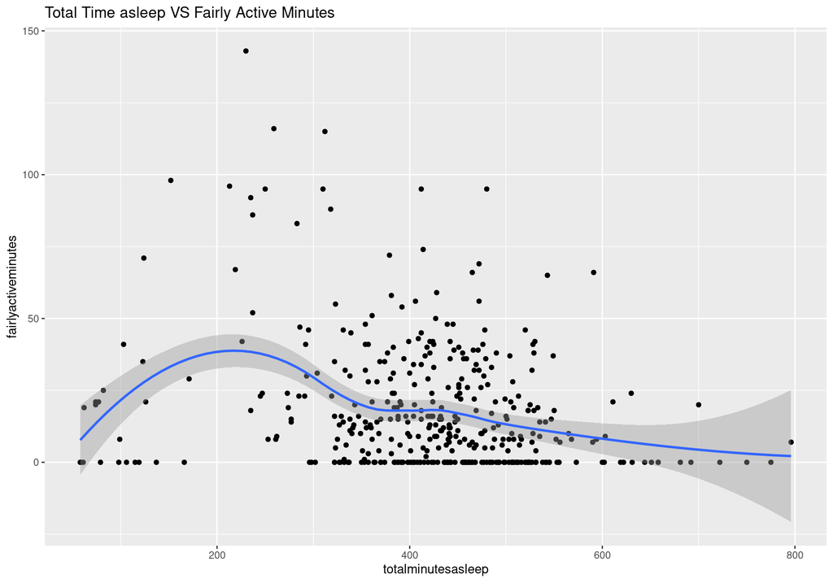

```r
ggplot(data=daily_merged,aes(x=totalminutesasleep,y=fairlyactiveminutes))+
  geom_point(color="black") + geom_smooth() + labs(title = "Total Time asleep VS Fairly Active Minutes")
```

According to the CDC, the average human sleeps 420 minutes or 7 hours a day.To consider being underslept would mean sleeping less than 7 hours and to be considered overslept they would sleep 541 minutes or 9 hours.

```r
sum(daily_merged$totalminutesasleep <= 419, na.rm=TRUE)
```

```
## [1] 181
```

```r
sum(daily_merged$totalminutesasleep >= 541, na.rm=TRUE)
```

```
## [1] 39
```

```r
nrow(sleep_daily)
```

```
## [1] 410
```

The following code shows us that there are 410 total observations in the sleep_daily data set.We will now add this information to out daily_merged data set.

```r
sleep_type <- daily_merged %>%
  mutate(sleep_type = case_when(totalminutesasleep <= 419 ~ "underslept",
                                totalminutesasleep >= 420 & totalminutesasleep <= 540 ~ "recommended",
                                totalminutesasleep >= 541 ~ "overslept"))
view(sleep_type)
```

```r
sleep_type_percent <- sleep_type %>%
  group_by(sleep_type) %>%
  summarise(total = n()) %>%
  mutate(totals = sum(total)) %>%
  group_by(sleep_type) %>%
  summarise(total_percent = total / totals) %>%
  mutate(labels = scales::percent(total_percent))

sleep_type_percent$sleep_type <- factor(sleep_type_percent$sleep_type, levels = c("underslept", "recommended", "overslept"))

head(sleep_type_percent)
```

```
## # A tibble: 3 × 3
##   sleep_type  total_percent labels
##   <fct>               <dbl> <chr>
## 1 overslept          0.0951 9.5%
## 2 recommended        0.463  46.3%
## 3 underslept         0.441  44.1%
```

We have no created a new table categorizing our findings into percentages based off of the CDC data and number of observations in the sleep_daily dataset.

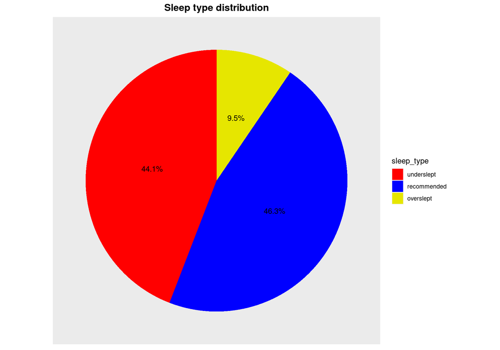

```r
sleep_type_percent %>%
  ggplot(aes(x="", y= total_percent, fill=sleep_type)) +
  geom_bar(stat = "identity", width = 1) +
  coord_polar("y", start = 0) +
  theme(axis.title.x= element_blank(),
        axis.title.y = element_blank(),
        panel.border = element_blank(),
        panel.grid = element_blank(),
        axis.ticks = element_blank(),
        axis.text.x = element_blank(),
        plot.title = element_text(hjust = 0.5, size=14, face = "bold")) +
  scale_fill_manual(values = c("red", "blue", "#e6e600")) +
  geom_text(aes(label = labels),
            position = position_stack(vjust = 0.5)) +
  labs(title = "Sleep type distribution")
```

The pie chart displayed above is showing the distribution of sleep from the observations. As we can see 46.3 % were in the recommended amount of sleep, 44.1% under slept, and 9.5% overslept.Now we will repeat the steps for the amount of steps taken per day.

Based off mayoclinic.org , it states that the average american walks around 4,000 steps a day or 2 miles. Based off a study at [UTsouthwestern medical center](https://utswmed.org/medblog/how-many-steps-per-day/) it says that we should be walking 7,000 stpes per day and walking less than 5,000 is considered sedentary.

```r
sum(daily_merged$totalsteps <= 4000, na.rm=TRUE)
```

```
## [1] 69
```

```r
sum(daily_merged$totalsteps >=3999 , na.rm=TRUE)
```

```
## [1] 341
```

```r
nrow(activity_daily)
```

```
## [1] 940
```

```r
steps_type <- daily_merged %>%
  mutate(steps_type = case_when(totalsteps <= 4000 ~ "below average",
                                totalsteps >= 5000 & totalsteps <= 7000 ~ "recommended",
                                totalsteps >= 5000 ~ "above average"))
head(steps_type)
```

```
##           id       date totalsteps totaldistance trackerdistance
## 1 1503960366 2016-04-12      13162          8.50            8.50
## 2 1503960366 2016-04-13      10735          6.97            6.97
## 3 1503960366 2016-04-15       9762          6.28            6.28
## 4 1503960366 2016-04-16      12669          8.16            8.16
## 5 1503960366 2016-04-17       9705          6.48            6.48
## 6 1503960366 2016-04-19      15506          9.88            9.88
##   loggedactivitiesdistance veryactivedistance moderatelyactivedistance
## 1                        0               1.88                     0.55
## 2                        0               1.57                     0.69
## 3                        0               2.14                     1.26
## 4                        0               2.71                     0.41
## 5                        0               3.19                     0.78
## 6                        0               3.53                     1.32
##   lightactivedistance sedentaryactivedistance veryactiveminutes
```

[output cut: 20 more lines]

Now we create a new table showing the percentages of the subjects number of steps based off of the 2022 study by UT southwestern medical.

```r
steps_type_percent <- steps_type %>%
  group_by(steps_type) %>%
  summarise(total = n()) %>%
  mutate(totals = sum(total)) %>%
  group_by(steps_type) %>%
  summarise(total_percent = total / totals) %>%
  mutate(labels = scales::percent(total_percent))

steps_type_percent$steps_type <- factor(steps_type_percent$steps_type, levels = c("below average", "recommended", "above average"))

head(steps_type_percent)
```

```
## # A tibble: 4 × 3
##   steps_type    total_percent labels
##   <fct>                 <dbl> <chr>
## 1 above average        0.629  62.9%
## 2 below average        0.168  16.8%
## 3 recommended          0.137  13.7%
## 4 <NA>                 0.0659 6.6%
```

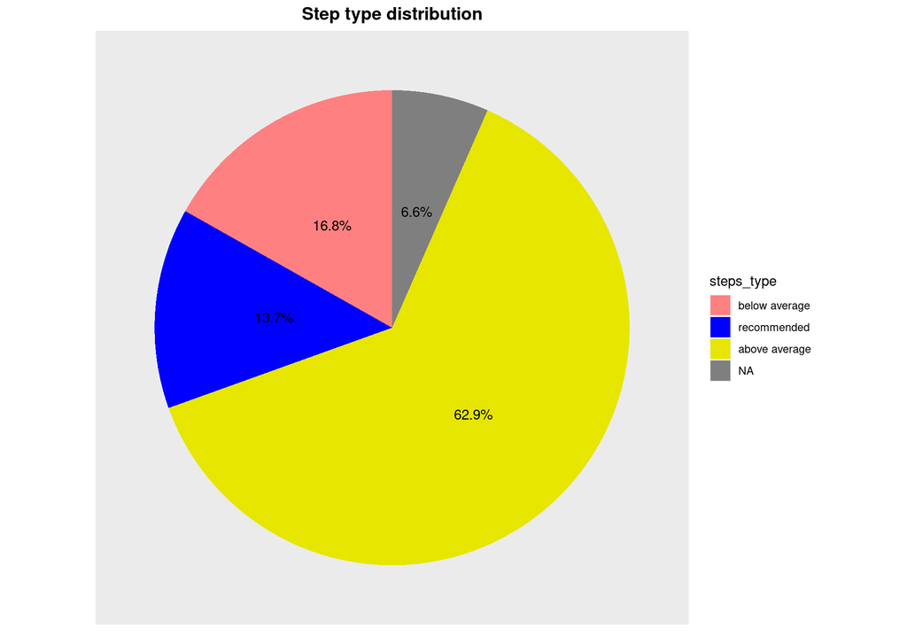

```r
steps_type_percent %>%
  ggplot(aes(x="", y= total_percent, fill=steps_type)) +
  geom_bar(stat = "identity", width = 1) +
  coord_polar("y", start = 0) +
  theme(axis.title.x= element_blank(),
        axis.title.y = element_blank(),
        panel.border = element_blank(),
        panel.grid = element_blank(),
        axis.ticks = element_blank(),
        axis.text.x = element_blank(),
        plot.title = element_text(hjust = 0.5, size=14, face = "bold")) +
  scale_fill_manual(values = c("#ff8080", "blue", "#e6e600")) +
  geom_text(aes(label = labels),
            position = position_stack(vjust = 0.5)) +
  labs(title = "Step type distribution")
```

## Summary and Reccomendations to the company

As we are aware, gathering data related to activity, sleep, stress, and reproductive health has enabled Bellabeat to provide women with valuable insights into their well-being and behaviors. Since its establishment in 2013, Bellabeat has experienced rapid growth and has swiftly established itself as a technology-driven wellness company focused on women’s health.

After a through analysis of the Fit Bit tracker data I have found different insights that will help the marketing team.

### Target market

Full-time working women who spend extended periods at their computers or in meetings, deeply engrossed in their tasks (as indicated by sedentary time data), engage in occasional light physical activity to promote their well-being, as suggested by the analysis of their activity patterns. Nevertheless, there is room for enhancing their daily physical activity to realize health advantages. It’s possible that they could benefit from insights on cultivating healthier habits or finding motivation to sustain their efforts.

### what they need to do to improve

The bellabeat app is a guide for women to build better habbits and live a healthy lifestyle.